# When Machine Learning Meets Cuisine

### **Cheng Ximen, CFA, FRM**

If you do not wish to see the raw code please click the button below

```python
%%HTML
<button onclick="$('.input, .prompt, .output_stderr, .output_error, .output_result').toggle();">Hide Code</button>
```

As I went through some post in Kaggle the other day, I found this playground competition called [What's Cooking](https://www.kaggle.com/c/whats-cooking/overview). It provide a dataset of various dishes along with its ingredients and cuisine types and asks participants to use model to predict the cuisine type based on the ingredients contained in each dish. As a foodie myself, this dataset immediately caught my eye and turned out to be a fun little project to work on. As usual let’s start with some charts to get an idea of what the data looks like.

```python
# import necessary libraries
import warnings
warnings.filterwarnings('ignore')
import pandas as pd
import numpy as np
import seaborn as sns
import matplotlib.pyplot as plt
import matplotlib.ticker as mtick
import matplotlib
%matplotlib inline
from sklearn.preprocessing import LabelEncoder
from sklearn.feature_extraction.text import CountVectorizer
from sklearn.feature_extraction.text import TfidfTransformer
from sklearn.cluster import KMeans, AgglomerativeClustering
matplotlib.rcParams.update({'font.size': 12})
from sklearn.decomposition import TruncatedSVD
import collections
import re
from adjustText import adjust_text
```

## Take a Peek of The Dataset

```python
# load and check data
data = pd.read_json('train.json')
data
```

|  | id | cuisine | ingredients |
| --- | --- | --- | --- |
| 0 | 10259 | greek | [romaine lettuce, black olives, grape tomatoes... |
| 1 | 25693 | southern_us | [plain flour, ground pepper, salt, tomatoes, g... |
| 2 | 20130 | filipino | [eggs, pepper, salt, mayonaise, cooking oil, g... |
| 3 | 22213 | indian | [water, vegetable oil, wheat, salt] |
| 4 | 13162 | indian | [black pepper, shallots, cornflour, cayenne pe... |
| ... | ... | ... | ... |
| 39769 | 29109 | irish | [light brown sugar, granulated sugar, butter, ... |
| 39770 | 11462 | italian | [KRAFT Zesty Italian Dressing, purple onion, b... |
| 39771 | 2238 | irish | [eggs, citrus fruit, raisins, sourdough starte... |
| 39772 | 41882 | chinese | [boneless chicken skinless thigh, minced garli... |
| 39773 | 2362 | mexican | [green chile, jalapeno chilies, onions, ground... |

39774 rows × 3 columns

```python
# delete id column
data = data[['cuisine','ingredients']]
```

As you can see the dataset has 39774 entries and contains the id of the dish, the type of cuisine and it's ingredients. The id is not very useful here, so I deleted the column from the dataset. Let's first look at the distribution of the target variable.

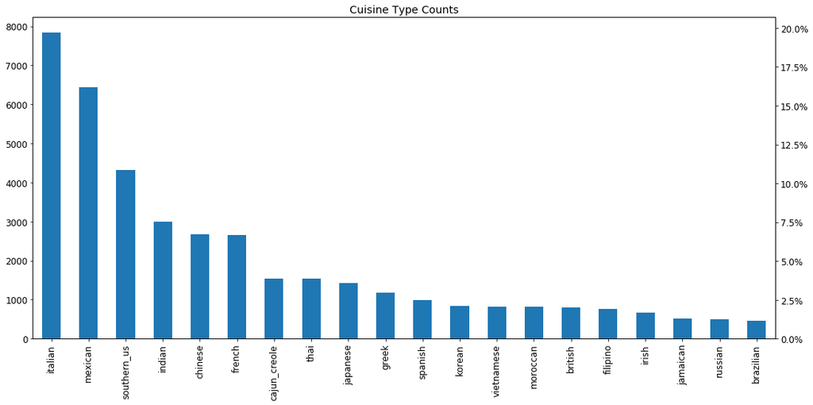

```python
# plot cuisine histogram
ax = data.cuisine.value_counts().plot(kind='bar',figsize=(18,8))
ax2 = ax.twinx()
(data.cuisine.value_counts()/len(data)*100).plot(ax=ax2,kind='bar')
ax2.yaxis.set_major_formatter(mtick.PercentFormatter())
plt.title('Cuisine Type Counts')
plt.show()
```

It seems Italian, Mexican and Sourthen US are the most common cuisines in this dataset, which takes up about 45%. I would go out on a limb to say this sample dataset is drawn from the US market. It's hard to tell from the italian cuisine, because pizza is now common in a lot of countries. But mexican and southern US cuisine just reminds me too much of Taco Bell and Denny's which I can see almost everywhere when I was in US and enjoyed very much myself as well.

Before we start digging into the ingredients. Let's do some data cleaning first.

```python
# select ingredients with other symbols
[i for ingredients in data.ingredients for i in ingredients if re.search("\(|@|®|\$\?",i)][:10]
```

```
['Bertolli® Classico Olive Oil',
 '(    oz.) tomato sauce',
 'Sargento® Traditional Cut Shredded Mozzarella Cheese',
 'besan (flour)',
 'Country Crock® Spread',
 '(10 oz.) frozen chopped spinach, thawed and squeezed dry',
 'Country Crock® Spread',
 'Knorr® Beef Bouillon',
 'OREO® Cookies',
 "I Can't Believe It's Not Butter!® Spread"]
```

Based on what I've seen in the samples shown above, I think it makes more sense to lose the words that contain weight, brand and handeling techniques like "chopped" from the ingredients.

```python
# text cleaning function
cleaner = lambda x: [re.sub(r'\(.*oz.\)|crushed|crumbles|ground|minced|chopped|sliced|.*® ',
                             '',
                             i.lower()).strip() for i in x]
# cleaning and save to dataframe
data['ingredients']=data['ingredients'].map(cleaner)
```

```python
# group ingredients based on cuisine
cuisine_group = data.groupby(by = 'cuisine', axis=0).sum()
```

## Bag of Word and Clustering on Cuisine Types

One common technique used in text mining is the bag of word, which is basicly to count how many times each word apprears in a text sample. With some grouping, I selected 15 most common ingredients in each cuisine type.

```python
# select top most common ingredients in each cuisine type
common_dic = {}
for cuisine in cuisine_group.index:
    common_dic[cuisine] = [i[0] for i in collections.Counter(cuisine_group.loc[cuisine,'ingredients']).most_common(15)]

pd.DataFrame(common_dic,index=list(range(1,16))).T
```

|  | 1 | 2 | 3 | 4 | 5 | 6 | 7 | 8 | 9 | 10 | 11 | 12 | 13 | 14 | 15 |
| --- | --- | --- | --- | --- | --- | --- | --- | --- | --- | --- | --- | --- | --- | --- | --- |
| brazilian | salt | onions | olive oil | garlic | lime | water | garlic cloves | tomatoes | cachaca | sugar | black pepper | pepper | coconut milk | sweetened condensed milk | eggs |
| british | salt | all-purpose flour | butter | milk | eggs | unsalted butter | sugar | onions | baking powder | large eggs | water | black pepper | pepper | heavy cream | flour |
| cajun_creole | salt | onions | garlic | black pepper | green bell pepper | celery | butter | cayenne pepper | olive oil | green onions | cajun seasoning | all-purpose flour | water | garlic cloves | vegetable oil |
| chinese | soy sauce | garlic | sesame oil | salt | corn starch | sugar | water | green onions | ginger | vegetable oil | scallions | fresh ginger | rice vinegar | garlic cloves | white pepper |
| filipino | salt | garlic | water | onions | soy sauce | pepper | oil | black pepper | sugar | carrots | fish sauce | bay leaves | vegetable oil | eggs | cooking oil |
| french | salt | sugar | all-purpose flour | unsalted butter | black pepper | olive oil | butter | water | large eggs | garlic cloves | onions | shallots | garlic | extra-virgin olive oil | dry white wine |
| greek | salt | olive oil | feta cheese | black pepper | garlic | dried oregano | garlic cloves | extra-virgin olive oil | pepper | fresh lemon juice | cucumber | purple onion | onions | lemon juice | tomatoes |
| indian | salt | onions | garlic | garam masala | cumin | water | turmeric | cumin seed | ginger | tomatoes | coriander | vegetable oil | oil | tumeric | chili powder |
| irish | salt | all-purpose flour | butter | onions | potatoes | sugar | baking soda | baking powder | milk | black pepper | carrots | pepper | water | eggs | unsalted butter |
| italian | salt | olive oil | black pepper | garlic | garlic cloves | grated parmesan cheese | extra-virgin olive oil | onions | water | pepper | butter | all-purpose flour | tomatoes | fresh basil | sugar |
| jamaican | salt | black pepper | allspice | onions | garlic | water | pepper | cinnamon | scallions | dried thyme | garlic cloves | nutmeg | vegetable oil | thyme | sugar |
| japanese | soy sauce | salt | mirin | sugar | water | sake | rice vinegar | vegetable oil | scallions | ginger | garlic | green onions | carrots | sesame oil | onions |
| korean | garlic | soy sauce | sesame oil | green onions | sugar | salt | water | sesame seeds | onions | scallions | ginger | black pepper | carrots | garlic cloves | gochujang base |
| mexican | salt | cumin | garlic | onions | olive oil | chili powder | jalapeno chilies | sour cream | tomatoes | avocado | cilantro | black pepper | corn tortillas | salsa | garlic cloves |
| moroccan | salt | olive oil | cumin | cinnamon | onions | black pepper | ginger | garlic cloves | water | garlic | coriander | carrots | paprika | couscous | extra-virgin olive oil |
| russian | salt | sugar | onions | all-purpose flour | sour cream | eggs | water | butter | unsalted butter | black pepper | large eggs | carrots | vegetable oil | milk | potatoes |
| southern_us | salt | butter | all-purpose flour | sugar | large eggs | black pepper | baking powder | water | unsalted butter | milk | buttermilk | eggs | pepper | onions | vanilla extract |
| spanish | salt | olive oil | garlic cloves | extra-virgin olive oil | onions | black pepper | garlic | tomatoes | water | pepper | red bell pepper | sugar | kosher salt | large eggs | fresh parsley |
| thai | fish sauce | garlic | salt | coconut milk | vegetable oil | soy sauce | sugar | water | green onions | garlic cloves | fresh lime juice | lime | shallots | lemongrass | lime juice |
| vietnamese | fish sauce | sugar | garlic | salt | water | carrots | shallots | soy sauce | black pepper | garlic cloves | vegetable oil | green onions | rice vinegar | beansprouts | fresh lime juice |

```python
# add all ingredients to one list
all_ingredients = data['ingredients'].sum()
# only save ingredients appeared over 2 times
ingredients_selected = [i[0] for i in collections.Counter(all_ingredients).most_common() if i[1]>2]

# create ingredient count by cuisine template
cuisine_count = pd.DataFrame(index = cuisine_group.index, columns = ingredients_selected).fillna(0)

# add count value to template
for cuis in cuisine_count.index:
    for ingre,count in dict(collections.Counter(cuisine_group.loc[cuis,:][0])).items():
        cuisine_count.loc[cuis,ingre] = count

# delete ingredient count less than theshold
cuisine_count = cuisine_count.dropna(axis='columns')
```

```python
# TF-IDF transformation
transformer = TfidfTransformer()
tfidf = transformer.fit_transform(cuisine_count)

# TruncatedSVD dimensionality reduction for easier visualization
SVD = TruncatedSVD(n_components=2)
reduced_data = SVD.fit_transform(tfidf)

# k means clustering
kmeans = KMeans(init='k-means++', n_clusters=4, n_init=10)
kmeans.fit(reduced_data)
labels =  kmeans.predict(reduced_data)
```

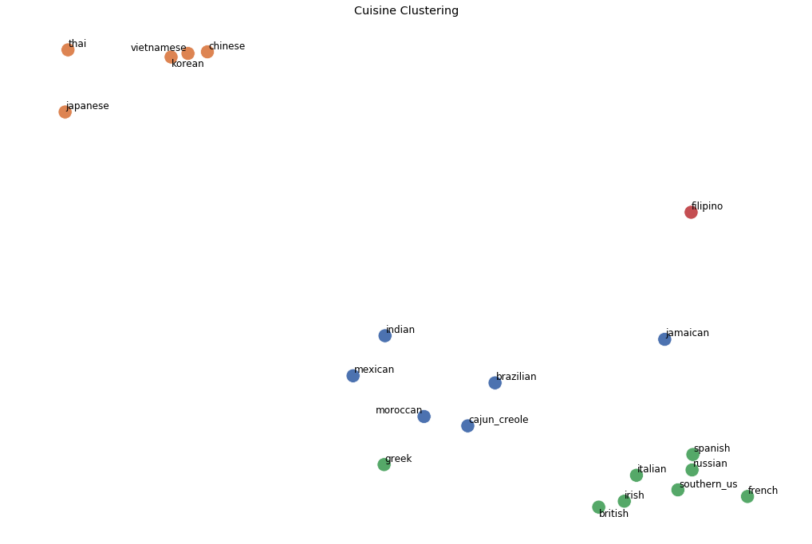

```python
# plot
fig,ax = plt.subplots(figsize=(18,12))
sns.scatterplot(x=0, y =1, ax = ax,data=pd.DataFrame(reduced_data),s=300,palette='deep',hue = labels, legend = None)
texts = [ax.text(reduced_data[i][0], reduced_data[i][1], cuisine_count.index[i]) for i in range(len(cuisine_count.index))]
plt.title('Cuisine Clustering')
adjust_text(texts)
plt.axis('off')
plt.show()
```

Cool. As suspected Asian cuisine cluster very well and seem to use very different ingredients than other parts of the world. One odd ball is the filipino cuisine, which seem to have its own unique style. I haven't had it myself so have no idea what makes it so different. The european cuisine have a pretty strong cluster as well. One interesting thing is the model says Southern US cuisine is also a member of this cluster. I guess there should be some historical linkage after all.

## Embedding and MLP to Predict Cuisine Type

Till now we used bag of word, Tfidf in feature engineering to analyze the relationship among different cuisine types. It works pretty well. However if we want to catch something more subtle besides word frequency, embedding seems to be the most powerful and convenient technique for job. For illustration purpose, I'll build a simple neural network to predict the cuisine type based on the ingredients using embedding.

```python
from sklearn.model_selection import train_test_split
from sklearn.preprocessing import OneHotEncoder
from tensorflow.keras.preprocessing.sequence import pad_sequences
from tensorflow.keras import layers
from tensorflow.keras import Sequential
import tensorflow as tf
import os
import datetime
%load_ext tensorboard
```

```python
def prepare_data(test_size=0.2):
    """Prepare train test dataset
    test_size -- proportion of test data
    """
    # create label encoder
    le = LabelEncoder().fit(ingredients_selected)

    # deleted ingredients appeared less than twice
    X_raw = data.ingredients.apply(lambda x: [i for i in x if i in ingredients_selected] )

    # label encode ingredients
    X_le = X_raw.apply(le.transform)

    # one hot encode cuisine type
    oe = OneHotEncoder(sparse = False)
    y = oe.fit_transform(data[['cuisine']])

    # pad ingredients
    max_len = 20
    X = pad_sequences(X_le,maxlen=max_len)

    # train test split
    return train_test_split(X, y, test_size=test_size, random_state=42)

X_train, X_test, y_train, y_test = prepare_data(test_size = 0.2)
```

```python
# create MLP model
def baseline_model():
    # create model
    model = Sequential([
        layers.Embedding(input_dim=4048, output_dim=8, mask_zero=True, input_length = max_len, name = 'Embedding'),
        layers.Flatten(),
        layers.Dropout(0.2),
        layers.Dense(20, activation='softmax', name = 'Dense_output')
    ])

    # Compile model
    model.compile(loss='categorical_crossentropy', optimizer='adam', metrics=['accuracy'])
    return model
```

```python
def train_model():
    # build model
    model = baseline_model()
    # log loss and metrics to tensorboard
    logdir = os.path.join("logs", datetime.datetime.now().strftime("%Y%m%d-%H%M%S"))
    tensorboard_callback = tf.keras.callbacks.TensorBoard(logdir, histogram_freq=1)
    # train model
    model.fit(x=X_train,
              y=y_train,
              epochs=20,
              validation_data=(X_test, y_test),
              callbacks=[tensorboard_callback])

    return model

model = train_model()
```

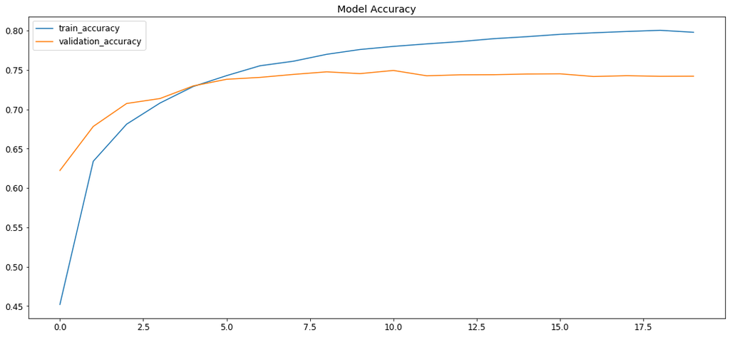

```python
accuracy_df = pd.DataFrame(model.history.history)[['accuracy','val_accuracy']]
accuracy_df.columns = ['train_accuracy','validation_accuracy']
accuracy_df.plot(figsize=(18,8),)
plt.title('Model Accuracy')
plt.show()
```

The model stopped improving after 10 epochs with accuracy on the validation dataset maxed out at around 75%. As a baseline model, I'd say it's not too bad. This is mainly to illustrate the application for embedding. In order to boost the score, for a small dataset like this, tree model will probably perform better. I'll stop this post here. It's been a fun ride. Hope you enjoyed it too.

Below are references to some posts I found very helpful:

- [Cultural Diffusion by Recipes](https://www.kaggle.com/alonalevy/cultural-diffusion-by-recipes)
- [Linear SVC on Bag of Words](https://www.kaggle.com/apapiu/linear-svc-on-bag-of-words)
- [Word2Vec with ingredients](https://www.kaggle.com/ccorbi/word2vec-with-ingredients)